# Group Project 7

Prajwal C N

05/05/2021

**Problem Statement**

Churn is an issue for telecom companies since it is expensive to obtain new customer than to prevent existing current customer from leaving.

Customer Churn Modeling has lot of consideration of late, as there are signs that a huge portion of corporate benefit originates from the current customers.

Organizations are exceptionally keen on recognizing customers who are probably going to churn and regularly embrace Data Mining techniques to assist them. In this project, we have identified the customers who are likely to churn and give an appropriate intercession to motivate them to stay based on available information.

#### Importing the Churn dataset

```r
Churn_Data <- read_csv("Churn_Train.csv")

# Inspecting data
head(Churn_Data)
```

| state | account_length | area_code | international_plan | voice_mail_plan | number_vmail_messages | total_day_minutes | total_day_calls | total_day_charge | total_eve_minutes | total_eve_calls | total_eve_charge | total_night_minutes | total_night_calls | total_night_charge | total_intl_minutes | total_intl_calls | total_intl_charge | number_customer_service_calls | churn |
| --- | --- | --- | --- | --- | --- | --- | --- | --- | --- | --- | --- | --- | --- | --- | --- | --- | --- | --- | --- |
| NV | 125 | area_code_510 | no | no | 0 | 2013.4 | 99 | 28.66 | 1107.6 | 107 | 14.93 | 243.3 | 92 | 10.95 | 10.9 | 7 | 2.94 | 0 | no |
| HI | 108 | area_code_415 | no | no | 0 | 291.6 | 99 | 49.57 | 221.1 | 93 | 18.79 | 229.2 | 110 | 10.31 | 14.0 | 9 | 3.78 | 2 | yes |
| DC | 82 | area_code_415 | no | no | 0 | 300.3 | 109 | 51.05 | 181.0 | 100 | 15.39 | 270.1 | 73 | 12.15 | 11.7 | 4 | 3.16 | 0 | yes |
| HI | NA | area_code_408 | no | yes | 30 | 110.3 | 71 | 18.75 | 182.4 | 108 | 15.50 | 183.8 | 88 | 8.27 | 11.0 | 8 | 2.97 | 2 | no |
| OH | 83 | area_code_415 | no | no | 0 | 337.4 | 120 | 57.36 | 227.4 | 116 | 19.33 | 153.9 | 114 | 6.93 | 15.8 | 7 | 4.27 | 0 | yes |
| MO | 89 | area_code_415 | no | no | 0 | 178.7 | 81 | 30.38 | NA | 74 | 19.86 | 131.9 | 120 | 5.94 | 9.1 | 4 | 2.46 | 1 | no |

Examining the dataset

```r
glimpse(Churn_Data)
```

```
## Rows: 3,333
## Columns: 20
## $ state                         <chr> "NV", "HI", "DC", "HI", "OH", "MO", "NC"~
## $ account_length                <dbl> 125, 108, 82, NA, 83, 89, 135, 28, 86, 6~
## $ area_code                     <chr> "area_code_510", "area_code_415", "area_~
## $ international_plan            <chr> "no", "no", "no", "no", "no", "no", "no"~
## $ voice_mail_plan               <chr> "no", "no", "no", "yes", "no", "no", "no~
## $ number_vmail_messages         <dbl> 0, 0, 0, 30, 0, 0, 0, 0, 0, 0, 0, NA, 32~
## $ total_day_minutes             <dbl> 2013.4, 291.6, 300.3, 110.3, 337.4, 178.~
## $ total_day_calls               <dbl> 99, 99, 109, 71, 120, 81, 81, 87, 115, 1~
## $ total_day_charge              <dbl> 28.66, 49.57, 51.05, 18.75, 57.36, 30.38~
## $ total_eve_minutes             <dbl> 1107.6, 221.1, 181.0, 182.4, 227.4, NA, ~
## $ total_eve_calls               <dbl> 107, 93, 100, 108, 116, 74, 114, 92, 112~
## $ total_eve_charge              <dbl> 14.93, 18.79, 15.39, 15.50, 19.33, 19.86~
## $ total_night_minutes           <dbl> 243.3, 229.2, 270.1, 183.8, 153.9, 131.9~
## $ total_night_calls             <dbl> 92, 110, 73, 88, 114, 120, 82, 112, 95, ~
## $ total_night_charge            <dbl> 10.95, 10.31, 12.15, 8.27, 6.93, 5.94, 9~
## $ total_intl_minutes            <dbl> 10.9, 14.0, 11.7, 11.0, 15.8, 9.1, 10.3,~
## $ total_intl_calls              <dbl> 7, 9, 4, 8, 7, 4, 6, 3, 7, 6, 7, NA, 4, ~
## $ total_intl_charge             <dbl> 2.94, 3.78, 3.16, 2.97, 4.27, 2.46, 2.78~
## $ number_customer_service_calls <dbl> 0, 2, 0, 2, 0, 1, 1, 3, 2, 4, 1, NA, 3, ~
## $ churn                         <chr> "no", "yes", "yes", "no", "yes", "no", "~
```

Summary statistics of dataset

```r
summary(Churn_Data)
```

```
##     state           account_length     area_code         international_plan
##  Length:3333        Min.   :-209.00   Length:3333        Length:3333
##  Class :character   1st Qu.:  72.00   Class :character   Class :character
##  Mode  :character   Median : 100.00   Mode  :character   Mode  :character
##                     Mean   :  97.32
##                     3rd Qu.: 127.00
##                     Max.   : 243.00
##                     NA's   :501
##  voice_mail_plan    number_vmail_messages total_day_minutes total_day_calls
##  Length:3333        Min.   :-10.000       Min.   :   0.0    Min.   :  0.0
##  Class :character   1st Qu.:  0.000       1st Qu.: 149.3    1st Qu.: 87.0
##  Mode  :character   Median :  0.000       Median : 190.5    Median :101.0
##                     Mean   :  7.333       Mean   : 418.9    Mean   :100.3
##                     3rd Qu.: 16.000       3rd Qu.: 237.8    3rd Qu.:114.0
##                     Max.   : 51.000       Max.   :2185.1    Max.   :165.0
##                     NA's   :200           NA's   :200       NA's   :200
##  total_day_charge total_eve_minutes total_eve_calls total_eve_charge
##  Min.   : 0.00    Min.   :   0.0    Min.   :  0.0   Min.   : 0.00
##  1st Qu.:24.45    1st Qu.: 170.5    1st Qu.: 87.0   1st Qu.:14.14
##  Median :30.65    Median : 209.9    Median :100.0   Median :17.09
##  Mean   :30.63    Mean   : 324.3    Mean   :100.1   Mean   :17.08
##  3rd Qu.:36.84    3rd Qu.: 257.6    3rd Qu.:114.0   3rd Qu.:20.00
##  Max.   :59.64    Max.   :1244.2    Max.   :170.0   Max.   :30.91
##  NA's   :200      NA's   :301       NA's   :200     NA's   :200
##  total_night_minutes total_night_calls total_night_charge total_intl_minutes
##  Min.   : 23.2       Min.   : 33.0     Min.   : 1.040     Min.   : 0.00
##  1st Qu.:167.3       1st Qu.: 87.0     1st Qu.: 7.530     1st Qu.: 8.50
##  Median :201.4       Median :100.0     Median : 9.060     Median :10.30
##  Mean   :201.2       Mean   :100.1     Mean   : 9.054     Mean   :10.23
##  3rd Qu.:235.3       3rd Qu.:113.0     3rd Qu.:10.590     3rd Qu.:12.10
##  Max.   :395.0       Max.   :175.0     Max.   :17.770     Max.   :20.00
##  NA's   :200                           NA's   :200        NA's   :200
##  total_intl_calls total_intl_charge number_customer_service_calls
##  Min.   : 0.00    Min.   :0.000     Min.   :0.000
##  1st Qu.: 3.00    1st Qu.:2.300     1st Qu.:1.000
##  Median : 4.00    Median :2.780     Median :1.000
##  Mean   : 4.47    Mean   :2.762     Mean   :1.561
##  3rd Qu.: 6.00    3rd Qu.:3.270     3rd Qu.:2.000
##  Max.   :20.00    Max.   :5.400     Max.   :9.000
##  NA's   :301      NA's   :200       NA's   :200
##     churn
##  Length:3333
##  Class :character
##  Mode  :character
##
##
##
##
```

#### Data cleaning and Exploratory Data Analysis

From glimpse we can see that, Some of the character variables can be converted into factors, So Converting character variables to factors.

```r
Churn_Data <- Churn_Data %>% mutate_if(is.character, as.factor)
```

and From summary we can see that, Churn_Data dataset has both NA and negative values, So investigating and handling further.

```r
# Checking NULL values in the dataset at column level.
colSums(is.na(Churn_Data))
```

```
##                         state                account_length
##                             0                           501
##                     area_code            international_plan
##                             0                             0
##               voice_mail_plan         number_vmail_messages
##                             0                           200
##             total_day_minutes               total_day_calls
##                           200                           200
##              total_day_charge             total_eve_minutes
##                           200                           301
##               total_eve_calls              total_eve_charge
##                           200                           200
##           total_night_minutes             total_night_calls
##                           200                             0
##            total_night_charge            total_intl_minutes
##                           200                           200
##              total_intl_calls             total_intl_charge
##                           301                           200
## number_customer_service_calls                         churn
##                           200                             0
```

```r
# Checking Negative values in the dataset at column level.
sapply(Churn_Data %>% select_if(is.numeric), function(x) {
  sum(x < 0, na.rm = TRUE)
})
```

```
##                account_length         number_vmail_messages
##                            51                           201
##             total_day_minutes               total_day_calls
##                             0                             0
##              total_day_charge             total_eve_minutes
##                             0                             0
##               total_eve_calls              total_eve_charge
##                             0                             0
##           total_night_minutes             total_night_calls
##                             0                             0
##            total_night_charge            total_intl_minutes
##                             0                             0
##              total_intl_calls             total_intl_charge
##                             0                             0
## number_customer_service_calls
##                             0
```

Since account length, and other numeric variables has few negative values, assuming them as erroneous values, we cannot void them because their corresponding churn value is “no” which means they are still associated with the provider.

```r
Churn_Data <-
  Churn_Data %>% mutate_if(is.numeric, function(x) {
    ifelse(x < 0, abs(x), x)
  })
```

```r
imputation_model <- preProcess(Churn_Data %>% select_if(is.numeric),method = "medianImpute")
data <- predict(imputation_model, Churn_Data %>% select_if(is.numeric))

Churn_Data <- Churn_Data %>% select(setdiff(names(Churn_Data), names(data))) %>% cbind(data)
```

**Visualization**

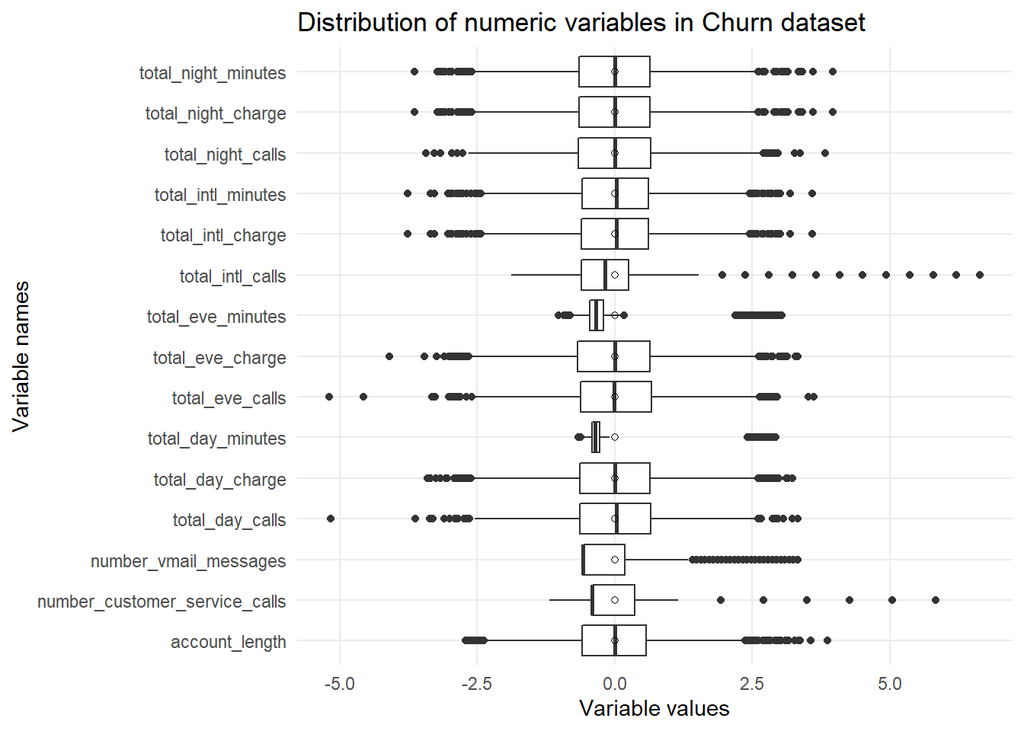

```r
Churn_Data %>% select_if(is.numeric) %>% mutate_all(scale) %>% gather("features","values") %>% na.omit() %>%
  ggplot(aes(x = features, y = values)) +
  geom_boxplot(show.legend = FALSE) +
  stat_summary(fun = mean, geom = "point", pch = 1) + # Add average to the boxplot
  scale_y_continuous(name = "Variable values", minor_breaks = NULL) +
  scale_fill_brewer(palette = "Set1") +
  coord_flip() +
  theme_minimal() +
  labs(x = "Variable names") +
  ggtitle(label = "Distribution of numeric variables in Churn dataset")
```

Visualizing distribution of Churn categorical variable.

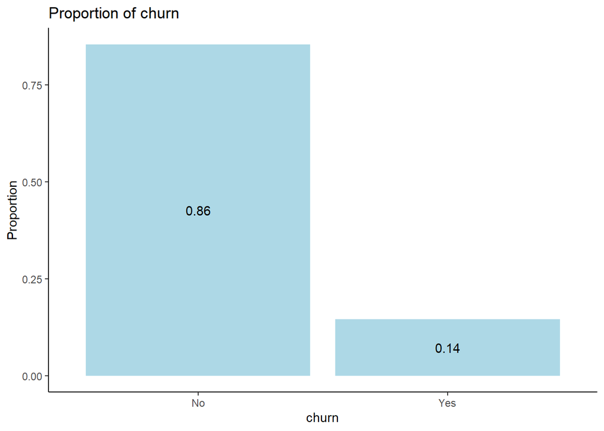

```r
ggplot(Churn_Data, aes(x=churn, y=..prop..,group = 1)) +
  geom_bar(fill="light blue") +
  theme_classic() +
  geom_text(aes(label=round(..prop..,2)),stat = "count",
            position = position_stack(vjust=0.5)) +
  labs(y = 'Proportion', title = "Proportion of churn") +
  scale_x_discrete(labels = c("No","Yes"))
```

From the above graph we can see that only around 14% of population are Churned and rest 86% are retained in the telecom network.

Proportion of area_code

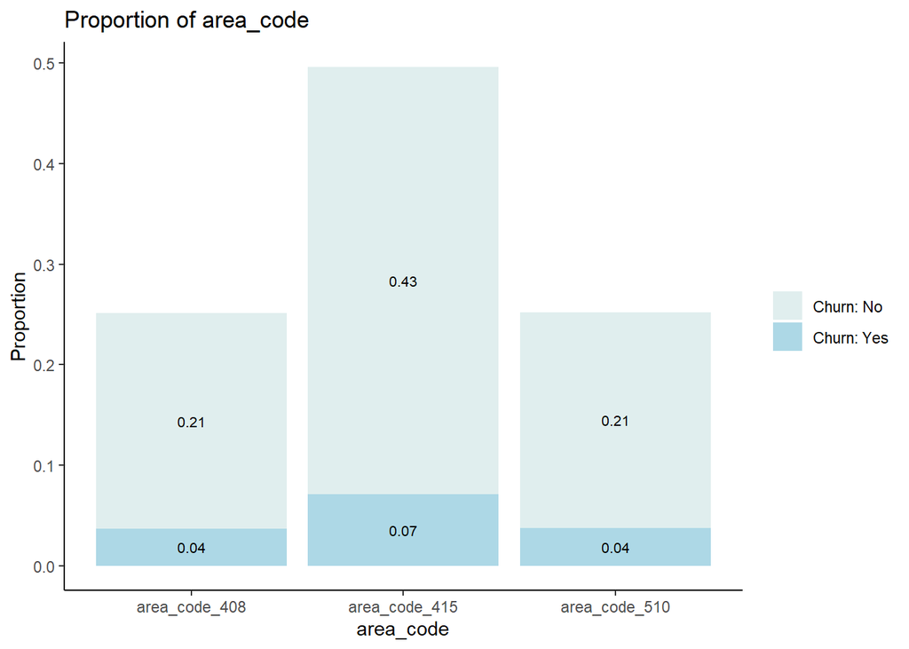

```r
as.data.frame(prop.table(table(Churn_Data[c("area_code","churn")]))) %>%
  ggplot(aes(x=area_code,y=Freq,fill=churn)) + geom_col() +
  geom_text(aes(label=round(Freq,2)),position = position_stack(vjust = 0.5),size=2.8) +
  theme_classic() + labs( y = 'Proportion', title = "Proportion of area_code") +
  theme(legend.title = element_blank()) +
  scale_fill_manual(labels = c("Churn: No","Churn: Yes"),
                    values = c("azure2","light blue"))
```

Proportion of international_plan

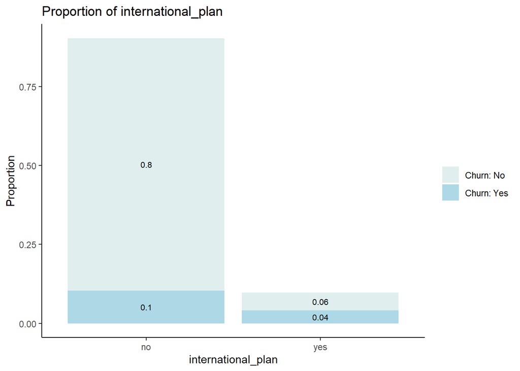

```r
as.data.frame(prop.table(table(Churn_Data[c("international_plan","churn")]))) %>%
  ggplot(aes(x=international_plan,y=Freq,fill=churn)) + geom_col() +
  geom_text(aes(label=round(Freq,2)),position = position_stack(vjust = 0.5),size=2.8) +
  theme_classic() + labs( y = 'Proportion', title = "Proportion of international_plan") +
  theme(legend.title = element_blank()) +
  scale_fill_manual(labels = c("Churn: No","Churn: Yes"),
                    values = c("azure2","light blue"))
```

Proportion of voice_mail_plan

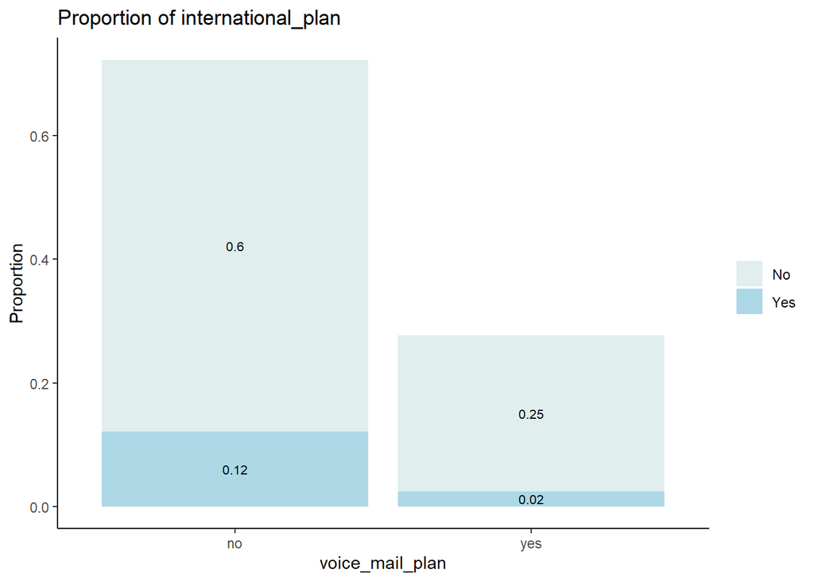

```r
as.data.frame(prop.table(table(Churn_Data[c("voice_mail_plan","churn")]))) %>%
  ggplot(aes(x=voice_mail_plan,y=Freq,fill=churn)) + geom_col() +
  geom_text(aes(label=round(Freq,2)),position = position_stack(vjust = 0.5),size=2.8) +
  theme_classic() + labs( y = 'Proportion', title = "Proportion of international_plan") +
  theme(legend.title = element_blank()) +
  scale_fill_manual(labels = c("No","Yes"),
                    values = c("azure2","light blue"))
```

**Correlation**

The image below will assist us in determining the variables’ correlation.

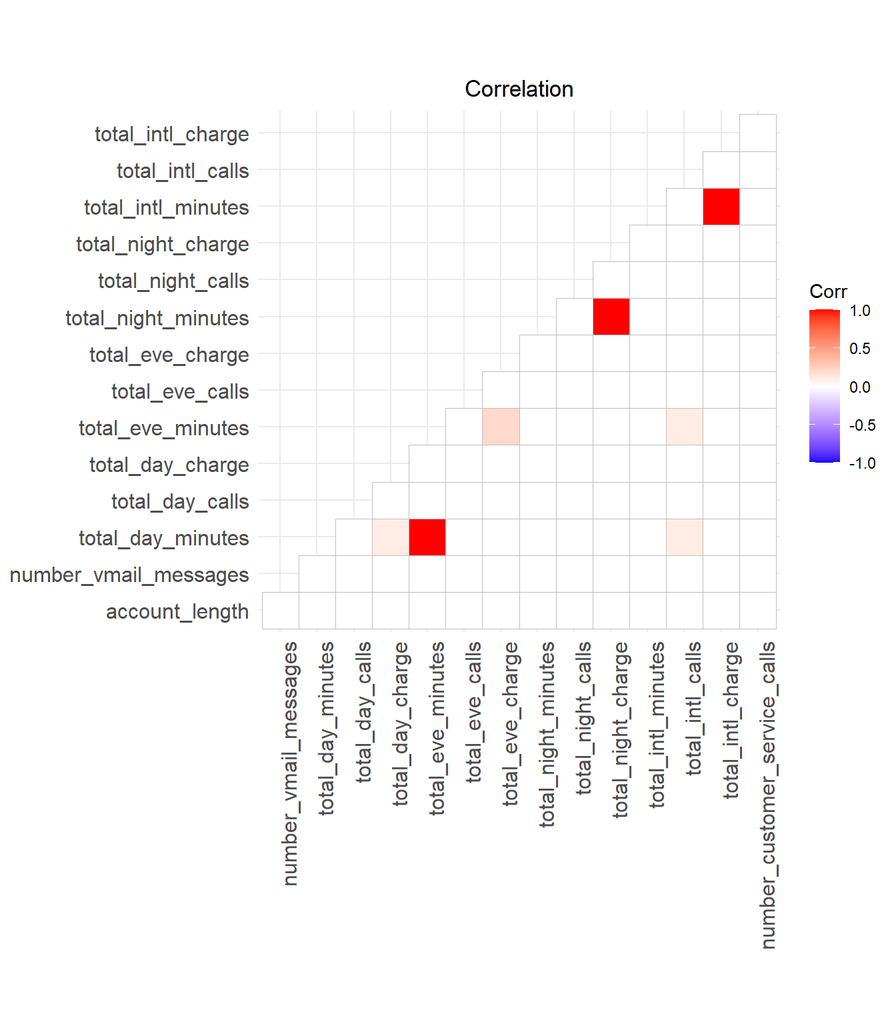

```r
Churn_Data_cor <- round(cor(Churn_Data %>% select_if(is.numeric)), 1)

ggcorrplot(Churn_Data_cor,  title = "Correlation", type = "lower") +
  theme(plot.title = element_text(hjust = 0.5),
        axis.text.x = element_text(angle = 90))
```

```r
Churn_Data <- Churn_Data %>% select(-state, -churn) %>%
  fastDummies::dummy_cols(., remove_selected_columns = TRUE) %>% mutate(state = Churn_Data$state, churn = Churn_Data$churn)
```

# Model Strategy:

The influence of various variables and their importance in predicting the outcome of the target variable has been demonstrated using a predictive model based on regression. Regression can be done in two ways: linear or logistic. Since the target variable in this data is categorical, a logistic regression model is an appropriate choice. It’s tempting to use linear regression as a model, but the performance likelihood may be negative or greater than 1, which is useless when predicting a binomial attribute. The ideal outcome for this model is a likelihood or probability of odds between 0 and 1, which is given by logistic regression.

#### Pre-Processing of data

**Splitting dataset into training (80%) and validation (20%) sets** The training set will be used to fit our model which we will be testing over the testing set.

```r
set.seed(12)
index <- createDataPartition(Churn_Data$churn, p=0.8, list=FALSE)
Churn_Data_train_df <- Churn_Data[index,]
Churn_Data_test_df <- Churn_Data[-index,]
```

```r
scaling <- preProcess(Churn_Data_train_df %>% select_if(is.numeric), method = c("center", "scale"))
Churn_Data_train_norm <- predict(scaling, Churn_Data_train_df %>% select_if(is.numeric))
Churn_Data_test_norm <- predict(scaling, Churn_Data_test_df %>% select_if(is.numeric))

Churn_Data_train_norm$churn <- Churn_Data_train_df$churn
Churn_Data_test_norm$churn <- Churn_Data_test_df$churn
```

#### Model Construction

```r
Model_1 <- glm(churn ~ ., data = Churn_Data_train_norm , family= "binomial")

summary(Model_1)
```

```
##
## Call:
## glm(formula = churn ~ ., family = "binomial", data = Churn_Data_train_norm)
##
## Deviance Residuals:
##     Min       1Q   Median       3Q      Max
## -2.1055  -0.5099  -0.3508  -0.2013   3.1185
##
## Coefficients: (3 not defined because of singularities)
##                                Estimate Std. Error z value Pr(>|z|)
## (Intercept)                   -2.300038   0.079590 -28.899  < 2e-16 ***
## account_length                 0.018545   0.062143   0.298  0.76538
## number_vmail_messages          0.127134   0.177494   0.716  0.47382
## total_day_minutes             -2.292991   1.250524  -1.834  0.06671 .
## total_day_calls                0.046819   0.061769   0.758  0.44847
## total_day_charge               0.853647   0.117549   7.262 3.81e-13 ***
## total_eve_minutes              2.184432   1.242318   1.758  0.07869 .
## total_eve_calls               -0.041535   0.061678  -0.673  0.50068
## total_eve_charge               0.068285   0.194636   0.351  0.72571
## total_night_minutes            1.835634  47.612807   0.039  0.96925
## total_night_calls              0.038145   0.062195   0.613  0.53967
## total_night_charge            -1.703082  47.611535  -0.036  0.97147
## total_intl_minutes            -5.955075  16.386684  -0.363  0.71630
## total_intl_calls              -0.186343   0.066424  -2.805  0.00503 **
## total_intl_charge              6.191261  16.384772   0.378  0.70553
## number_customer_service_calls  0.689509   0.056961  12.105  < 2e-16 ***
## area_code_area_code_408        0.005171   0.075775   0.068  0.94559
## area_code_area_code_415       -0.025656   0.075043  -0.342  0.73244
## area_code_area_code_510              NA         NA      NA       NA
## international_plan_no         -0.603710   0.048133 -12.542  < 2e-16 ***
## international_plan_yes               NA         NA      NA       NA
## voice_mail_plan_no             0.560696   0.181780   3.084  0.00204 **
## voice_mail_plan_yes                  NA         NA      NA       NA
## ---
## Signif. codes:  0 '***' 0.001 '**' 0.01 '*' 0.05 '.' 0.1 ' ' 1
##
## (Dispersion parameter for binomial family taken to be 1)
##
##     Null deviance: 2209  on 2666  degrees of freedom
## Residual deviance: 1740  on 2647  degrees of freedom
## AIC: 1780
##
## Number of Fisher Scoring iterations: 6
```

Now we can analyze the fitting and interpret what the model is telling us.

Predict values using based on Model_1.

```r
pred_probs <- predict(object = Model_1,Churn_Data_test_norm, type = "response")

# Finding accuracy for the model
# Function to find the accuracy, based on probability(0.5 - 0.9)
sequence1 <- data.frame(pred_cutoff = seq(0.5,0.9,0.1), pred_accuracy = rep(0,5))

for (i in 1:5){
  Model_11 <- as.factor(ifelse(pred_probs > sequence1$pred_cutoff[i], "yes", "no"))
  sequence1[i,2] <- confusionMatrix(Model_11,Churn_Data_test_df$churn )$overall[1]
}

# Shows the probability with its accuracy
sequence1
```

| pred_cutoff | pred_accuracy |
| --- | --- |
| 0.5 | 0.8678679 |
| 0.6 | 0.8693694 |
| 0.7 | 0.8663664 |
| 0.8 | 0.8603604 |
| 0.9 | 0.8588589 |

# Assigning labels based on maximum probability prediction

```r
Model_Pre_lables <- as.factor(ifelse(pred_probs>sequence1$pred_cutoff[which.max(sequence1$pred_accuracy)] ,"yes","no"))
```

#### Performance Metrics

```r
CrossTable(x=Churn_Data_test_norm$churn, y = Model_Pre_lables, prop.chisq = FALSE)
```

```
##
##
##    Cell Contents
## |-------------------------|
## |                       N |
## |           N / Row Total |
## |           N / Col Total |
## |         N / Table Total |
## |-------------------------|
##
##
## Total Observations in Table:  666
##
##
##                            | Model_Pre_lables
## Churn_Data_test_norm$churn |        no |       yes | Row Total |
## ---------------------------|-----------|-----------|-----------|
##                         no |       563 |         7 |       570 |
##                            |     0.988 |     0.012 |     0.856 |
##                            |     0.876 |     0.304 |           |
##                            |     0.845 |     0.011 |           |
## ---------------------------|-----------|-----------|-----------|
##                        yes |        80 |        16 |        96 |
##                            |     0.833 |     0.167 |     0.144 |
##                            |     0.124 |     0.696 |           |
##                            |     0.120 |     0.024 |           |
## ---------------------------|-----------|-----------|-----------|
##               Column Total |       643 |        23 |       666 |
##                            |     0.965 |     0.035 |           |
## ---------------------------|-----------|-----------|-----------|
##
##
```

```r
confusionMatrix(Model_Pre_lables,Churn_Data_test_norm$churn)
```

```
## Confusion Matrix and Statistics
##
##           Reference
## Prediction  no yes
##        no  563  80
##        yes   7  16
##
##                Accuracy : 0.8694
##                  95% CI : (0.8414, 0.894)
##     No Information Rate : 0.8559
##     P-Value [Acc > NIR] : 0.1746
##
##                   Kappa : 0.2258
##
##  Mcnemar's Test P-Value : 1.171e-14
##
##             Sensitivity : 0.9877
##             Specificity : 0.1667
##          Pos Pred Value : 0.8756
##          Neg Pred Value : 0.6957
##              Prevalence : 0.8559
##          Detection Rate : 0.8453
##    Detection Prevalence : 0.9655
##       Balanced Accuracy : 0.5772
##
##        'Positive' Class : no
##
```

#### AUC of the model 1

```r
roc(Churn_Data_test_df$churn, pred_probs)
```

```
##
## Call:
## roc.default(response = Churn_Data_test_df$churn, predictor = pred_probs)
##
## Data: pred_probs in 570 controls (Churn_Data_test_df$churn no) < 96 cases (Churn_Data_test_df$churn yes).
## Area under the curve: 0.7973
```

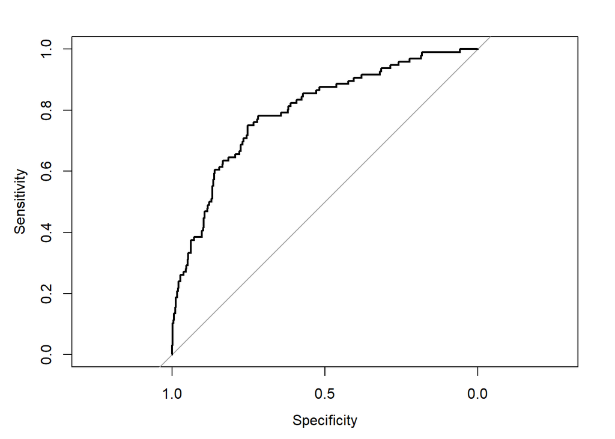

```r
plot.roc(roc(Churn_Data_test_df$churn, pred_probs))
```

#### Constructing decision tree model on above partitioned data

#### Model Construction

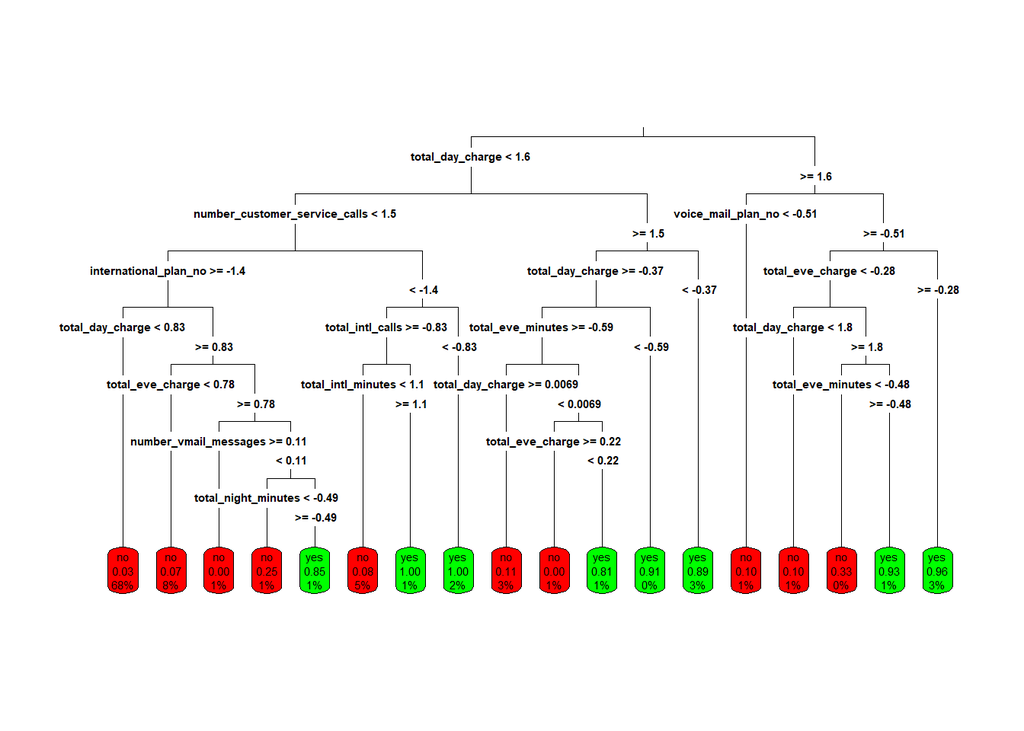

```r
Model_2 <- rpart(churn ~ ., data = Churn_Data_train_norm, method = "class")

rpart.plot(Model_2, type = 3, box.palette = c("red", "green"), fallen.leaves = TRUE)
```

Now we can analyze the fitting and interpret what the model is telling us.

Predict values using based on Model_2.

```r
pred_labels <- predict(object = Model_2,Churn_Data_test_norm, type = "class")
pred_probs <- predict(object = Model_2,Churn_Data_test_norm)
```

#### Performance Metrics

```r
CrossTable(x=Churn_Data_test_norm$churn, y = pred_labels, prop.chisq = FALSE)
```

```
##
##
##    Cell Contents
## |-------------------------|
## |                       N |
## |           N / Row Total |
## |           N / Col Total |
## |         N / Table Total |
## |-------------------------|
##
##
## Total Observations in Table:  666
##
##
##                            | pred_labels
## Churn_Data_test_norm$churn |        no |       yes | Row Total |
## ---------------------------|-----------|-----------|-----------|
##                         no |       563 |         7 |       570 |
##                            |     0.988 |     0.012 |     0.856 |
##                            |     0.937 |     0.108 |           |
##                            |     0.845 |     0.011 |           |
## ---------------------------|-----------|-----------|-----------|
##                        yes |        38 |        58 |        96 |
##                            |     0.396 |     0.604 |     0.144 |
##                            |     0.063 |     0.892 |           |
##                            |     0.057 |     0.087 |           |
## ---------------------------|-----------|-----------|-----------|
##               Column Total |       601 |        65 |       666 |
##                            |     0.902 |     0.098 |           |
## ---------------------------|-----------|-----------|-----------|
##
##
```

```r
confusionMatrix(pred_labels,Churn_Data_test_norm$churn)
```

```
## Confusion Matrix and Statistics
##
##           Reference
## Prediction  no yes
##        no  563  38
##        yes   7  58
##
##                Accuracy : 0.9324
##                  95% CI : (0.9106, 0.9503)
##     No Information Rate : 0.8559
##     P-Value [Acc > NIR] : 5.285e-10
##
##                   Kappa : 0.6837
##
##  Mcnemar's Test P-Value : 7.744e-06
##
##             Sensitivity : 0.9877
##             Specificity : 0.6042
##          Pos Pred Value : 0.9368
##          Neg Pred Value : 0.8923
##              Prevalence : 0.8559
##          Detection Rate : 0.8453
##    Detection Prevalence : 0.9024
##       Balanced Accuracy : 0.7959
##
##        'Positive' Class : no
##
```

```r
roc(Churn_Data_test_df$churn, pred_probs[,2])
```

```
##
## Call:
## roc.default(response = Churn_Data_test_df$churn, predictor = pred_probs[,     2])
##
## Data: pred_probs[, 2] in 570 controls (Churn_Data_test_df$churn no) < 96 cases (Churn_Data_test_df$churn yes).
## Area under the curve: 0.847
```

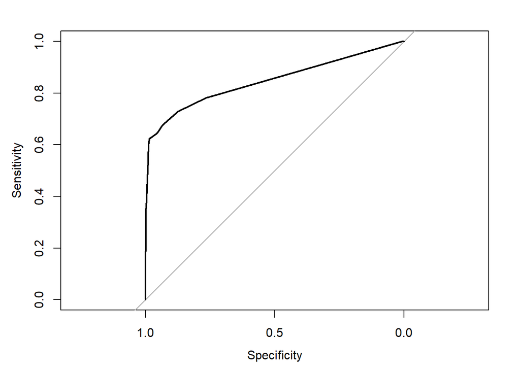

```r
plot.roc(roc(Churn_Data_test_df$churn, pred_probs[,2]))
```

#### Predicting for Customers_To_Predict

```r
load("C:/Users/prajw/Downloads/Customers_To_Predict.RData")
Customers_To_Predict_data  <- Customers_To_Predict
Customers_To_Predict <- Customers_To_Predict %>% select(-state) %>% fastDummies::dummy_cols(., remove_selected_columns = TRUE)
Customers_To_Predict <- as.data.frame(scale(Customers_To_Predict))
predict_labels <- predict(object = Model_2, Customers_To_Predict, type = "class")


Customers_To_Predict <- Customers_To_Predict_data %>% mutate(Churn_Prob = predict_labels)

table(Customers_To_Predict$Churn_Prob)
```

```
##
##  no yes
## 903  97
```